# Getting familiar with dMrs

Paul Little, Reuben Adatorwovor

Last Updated: 11/05/2021

# 1 Introduction

This **dMrs** package is designed to fit survival data to the corresponding manuscript.

```r
library(dMrs)
```

# 2 Simulation

Specify underlying arguments and parameters.

```r
copula = c("Clayton","Gumbel")[1]
dist1 = c("weibull","expweibull")[1]
NN = 2e2 # sample size
theta = 3/2
alpha1 = 5
lambda1 = 1.2
kappa1 = 2
kappa1 = ifelse(dist1 == "weibull",1,kappa1)
alpha2 = 2
lambda2 = 2.1
propC = 0.1
```

## 2.1 One replicate

Simulate a dataset.

```r
set.seed(1)
one_rep = sim_replicate(copula = copula,dist1 = dist1,
  NN = NN,theta = theta,alpha1 = alpha1,lambda1 = lambda1,
  kappa1 = kappa1,alpha2 = alpha2,lambda2 = lambda2,
  propC = propC,show = TRUE)
```

```
Fri Nov 05 15:43:34 2021: Simulate dataset ...

  0   1
0.1 0.9
```

```r
str(one_rep)
```

```
List of 2
 $ DATA  :'data.frame': 200 obs. of  9 variables:
  ..$ T1     : num [1:200] 0.949 1.03 1.162 1.428 0.891 ...
  ..$ T2     : num [1:200] 1.042 1.151 2.026 1.903 0.792 ...
  ..$ T      : num [1:200] 0.949 1.03 1.162 1.428 0.792 ...
  ..$ D      : num [1:200] 1 1 1 1 0 1 1 1 1 1 ...
  ..$ C      : num [1:200] 1.87 6.01 9.87 1.92 10.19 ...
  ..$ time   : num [1:200] 0.949 1.03 1.162 1.428 0.792 ...
  ..$ delta  : num [1:200] 1 1 1 1 1 1 1 1 1 1 ...
  ..$ dens_t2: num [1:200] 0.351 0.367 0.388 0.408 0.311 ...
  ..$ surv_t2: num [1:200] 0.815 0.786 0.736 0.63 0.867 ...
 $ PARAMS:'data.frame': 1 obs. of  8 variables:
  ..$ copula : chr "Clayton"
  ..$ NN     : num 200
  ..$ theta  : num 1.5
  ..$ alpha1 : num 5
  ..$ lambda1: num 1.2
  ..$ kappa1 : num 1
  ..$ alpha2 : num 2
  ..$ lambda2: num 2.1
```

```r
head(one_rep$DATA)
```

```
         T1        T2         T D         C      time delta   dens_t2   surv_t2
1 0.9485363 1.0417466 0.9485363 1  1.867922 0.9485363     1 0.3507852 0.8154474
2 1.0297904 1.1511616 1.0297904 1  6.012434 1.0297904     1 0.3672027 0.7862590
3 1.1617941 2.0261455 1.1617941 1  9.867206 1.1617941     1 0.3879684 0.7363356
4 1.4282242 1.9032363 1.4282242 1  1.919654 1.4282242     1 0.4078561 0.6296789
5 0.8906632 0.7917688 0.7917688 0 10.186498 0.7917688     1 0.3114965 0.8674879
6 1.4158579 2.4415124 1.4158579 1  2.963815 1.4158579     1 0.4075621 0.6347208
```

```r
table(one_rep$DATA$D)
```

```
  0   1
 39 161
```

```r
table(one_rep$DATA$delta)
```

```
  0   1
 20 180
```

For a given parameter grid and theta value, first, run a grid search. If `show = TRUE`, verbose output is provided and a heatmap of the log likelihood is generated. Then run parameter optimization for the true `theta` value and an arbitrary `theta` value for fixed `theta` (`upTHETA = 0`). We are also assuming the first event time is Weibull distributed (`upKAPPA = 0`).

```r
opt_out = opt_replicate(REP = one_rep,
  param_grid = seq(-1,3,0.25),
    theta = one_rep$PARAMS$theta,
  upKAPPA = 0,
  upTHETA = 0,
  show = TRUE)
```

```
Fri Nov 05 15:43:34 2021: Grid search for initial parameters ...
Num grid points = 289
289 out of 289 done
Fri Nov 05 15:43:35 2021: Find all local optimums
............................289 out of 289
Fri Nov 05 15:43:35 2021: Two-dimensional plot of the log likelihood ...
```

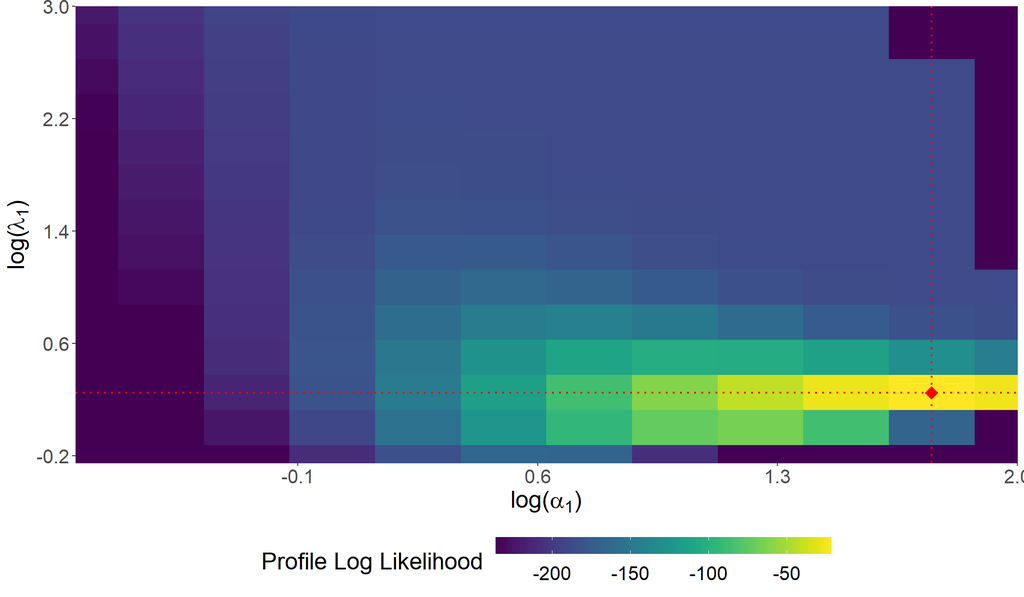

```
Fri Nov 05 15:43:36 2021: BFGS optimization ...
.
Fri Nov 05 15:43:36 2021: Get covariance ...
```

```r
str(opt_out)
```

```
List of 9
 $ GRID : num [1:289, 1:5] -1 -1 -1 -1 -1 -1 -1 -1 -1 -1 ...
 $ GPROF:'data.frame':  289 obs. of  5 variables:
  ..$ log_alpha1 : num [1:289] -1 -1 -1 -1 -1 -1 -1 -1 -1 -1 ...
  ..$ log_lambda1: num [1:289] -1 -0.75 -0.5 -0.25 0 0.25 0.5 0.75 1 1.25 ...
  ..$ log_kappa1 : num [1:289] 0 0 0 0 0 0 0 0 0 0 ...
  ..$ log_theta  : num [1:289] 0.405 0.405 0.405 0.405 0.405 ...
  ..$ LL         : num [1:289] -365 -351 -339 -329 -319 ...
 $ GOPT :'data.frame':  1 obs. of  12 variables:
  ..$ log_alpha1 : num 1.75
  ..$ log_lambda1: num 0.25
  ..$ log_kappa1 : num 0
  ..$ log_theta  : num 0.405
  ..$ LL         : num -22.1
  ..$ fin_LL     : num -14.1
  ..$ nGRAD      : num 7.64e-07
  ..$ fin_logA   : num 1.72
  ..$ fin_logL   : num 0.189
  ..$ fin_logK   : num 0
  ..$ fin_logT   : num 0.405
  ..$ neg_var    : logi FALSE
 $ out  :'data.frame':  4 obs. of  5 variables:
  ..$ PARS  : chr [1:4] "log_alpha1" "log_lambda1" "log_kappa1" "log_theta"
  ..$ EST   : num [1:4] 1.721 0.189 0 0.405
  ..$ SE    : num [1:4] 0.068 0.0152 0 0
  ..$ lowCI : num [1:4] 1.588 0.159 0 0.405
  ..$ highCI: num [1:4] 1.854 0.219 0 0.405
 $ cout :'data.frame':  4 obs. of  7 variables:
  ..$ PARS    : chr [1:4] "alpha1" "lambda1" "kappa1" "theta"
  ..$ EST     : num [1:4] 5.59 1.21 1 1.5
  ..$ SE      : num [1:4] 0.3803 0.0184 0 0
  ..$ lowCI   : num [1:4] 4.85 1.17 1 1.5
  ..$ highCI  : num [1:4] 6.34 1.24 1 1.5
  ..$ lowCI_2 : num [1:4] 4.89 1.17 1 1.5
  ..$ highCI_2: num [1:4] 6.39 1.25 1 1.5
 $ LL   : num -14.1
 $ GRAD : Named num [1:4] -5.14e-07 -5.65e-07 0.00 0.00
  ..- attr(*, "names")= chr [1:4] "log_alpha1" "log_lambda1" "log_kappa1" "log_theta"
 $ HESS : num [1:4, 1:4] -255 446 0 0 446 ...
  ..- attr(*, "dimnames")=List of 2
  .. ..$ : chr [1:4] "log_alpha1" "log_lambda1" "log_kappa1" "log_theta"
  .. ..$ : chr [1:4] "log_alpha1" "log_lambda1" "log_kappa1" "log_theta"
 $ COVAR: num [1:4, 1:4] 0.004626 0.000405 0 0 0.000405 ...
  ..- attr(*, "dimnames")=List of 2
  .. ..$ : chr [1:4] "log_alpha1" "log_lambda1" "log_kappa1" "log_theta"
  .. ..$ : chr [1:4] "log_alpha1" "log_lambda1" "log_kappa1" "log_theta"
```

```r
opt_out = opt_replicate(REP = one_rep,
  param_grid = seq(-1,3,0.25),
  theta = 2,
  upKAPPA = 0,
  upTHETA = 0,
  show = TRUE)
```

```
Fri Nov 05 15:43:36 2021: Grid search for initial parameters ...
Num grid points = 289
289 out of 289 done
Fri Nov 05 15:43:36 2021: Find all local optimums
............................289 out of 289
Fri Nov 05 15:43:37 2021: Two-dimensional plot of the log likelihood ...
```

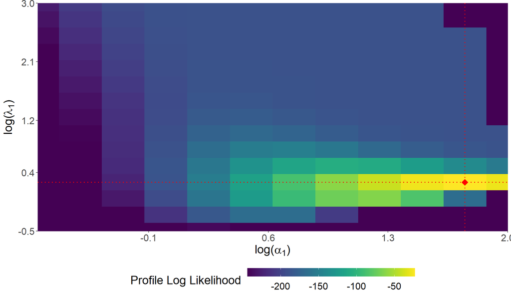

```
Fri Nov 05 15:43:37 2021: BFGS optimization ...
.
Fri Nov 05 15:43:37 2021: Get covariance ...
```

```r
str(opt_out)
```

```
List of 9
 $ GRID : num [1:289, 1:5] -1 -1 -1 -1 -1 -1 -1 -1 -1 -1 ...
 $ GPROF:'data.frame':  289 obs. of  5 variables:
  ..$ log_alpha1 : num [1:289] -1 -1 -1 -1 -1 -1 -1 -1 -1 -1 ...
  ..$ log_lambda1: num [1:289] -1 -0.75 -0.5 -0.25 0 0.25 0.5 0.75 1 1.25 ...
  ..$ log_kappa1 : num [1:289] 0 0 0 0 0 0 0 0 0 0 ...
  ..$ log_theta  : num [1:289] 0.693 0.693 0.693 0.693 0.693 ...
  ..$ LL         : num [1:289] -375 -363 -351 -342 -333 ...
 $ GOPT :'data.frame':  1 obs. of  12 variables:
  ..$ log_alpha1 : num 1.75
  ..$ log_lambda1: num 0.25
  ..$ log_kappa1 : num 0
  ..$ log_theta  : num 0.693
  ..$ LL         : num -23.6
  ..$ fin_LL     : num -13.9
  ..$ nGRAD      : num 0.00665
  ..$ fin_logA   : num 1.7
  ..$ fin_logL   : num 0.183
  ..$ fin_logK   : num 0
  ..$ fin_logT   : num 0.693
  ..$ neg_var    : logi FALSE
 $ out  :'data.frame':  4 obs. of  5 variables:
  ..$ PARS  : chr [1:4] "log_alpha1" "log_lambda1" "log_kappa1" "log_theta"
  ..$ EST   : num [1:4] 1.698 0.183 0 0.693
  ..$ SE    : num [1:4] 0.0673 0.0152 0 0
  ..$ lowCI : num [1:4] 1.566 0.154 0 0.693
  ..$ highCI: num [1:4] 1.829 0.213 0 0.693
 $ cout :'data.frame':  4 obs. of  7 variables:
  ..$ PARS    : chr [1:4] "alpha1" "lambda1" "kappa1" "theta"
  ..$ EST     : num [1:4] 5.46 1.2 1 2
  ..$ SE      : num [1:4] 0.3675 0.0182 0 0
  ..$ lowCI   : num [1:4] 4.74 1.17 1 2
  ..$ highCI  : num [1:4] 6.18 1.24 1 2
  ..$ lowCI_2 : num [1:4] 4.79 1.17 1 2
  ..$ highCI_2: num [1:4] 6.23 1.24 1 2
 $ LL   : num -13.9
 $ GRAD : Named num [1:4] -0.00322 -0.00582 0 0
  ..- attr(*, "names")= chr [1:4] "log_alpha1" "log_lambda1" "log_kappa1" "log_theta"
 $ HESS : num [1:4, 1:4] -260 448 0 0 448 ...
  ..- attr(*, "dimnames")=List of 2
  .. ..$ : chr [1:4] "log_alpha1" "log_lambda1" "log_kappa1" "log_theta"
  .. ..$ : chr [1:4] "log_alpha1" "log_lambda1" "log_kappa1" "log_theta"
 $ COVAR: num [1:4, 1:4] 0.00453 0.000396 0 0 0.000396 ...
  ..- attr(*, "dimnames")=List of 2
  .. ..$ : chr [1:4] "log_alpha1" "log_lambda1" "log_kappa1" "log_theta"
  .. ..$ : chr [1:4] "log_alpha1" "log_lambda1" "log_kappa1" "log_theta"
```

We can determine if the optimization converged or not by looking at the gradient and check out other quantities when evaluated at the MLE.

```r
# MLEs (unconstrained)
opt_out$out
```

```
         PARS       EST         SE     lowCI    highCI
1  log_alpha1 1.6975310 0.06730259 1.5656179 1.8294440
2 log_lambda1 0.1833263 0.01516364 0.1536055 0.2130470
3  log_kappa1 0.0000000 0.00000000 0.0000000 0.0000000
4   log_theta 0.6931472 0.00000000 0.6931472 0.6931472
```

```r
# MLEs (constrained)
opt_out$cout
```

```
     PARS      EST         SE    lowCI   highCI  lowCI_2 highCI_2
1  alpha1 5.460449 0.36750233 4.740144 6.180753 4.785631 6.230422
2 lambda1 1.201206 0.01821466 1.165506 1.236907 1.166031 1.237443
3  kappa1 1.000000 0.00000000 1.000000 1.000000 1.000000 1.000000
4   theta 2.000000 0.00000000 2.000000 2.000000 2.000000 2.000000
```

```r
# Log-likelihood
opt_out$LL
```

```
[1] -13.91686
```

```r
# Gradient, Score, first derivative of log-likelihood
opt_out$GRAD
```

```
  log_alpha1  log_lambda1   log_kappa1    log_theta
-0.003220652 -0.005822119  0.000000000  0.000000000
```

```r
# Hessian, second derivative of log-likelihood
opt_out$HESS
```

```
            log_alpha1 log_lambda1 log_kappa1 log_theta
log_alpha1   -259.8934    447.5629          0         0
log_lambda1   447.5629  -5119.7858          0         0
log_kappa1      0.0000      0.0000          0         0
log_theta       0.0000      0.0000          0         0
```

```r
# Covariance matrix
opt_out$COVAR
```

```
              log_alpha1  log_lambda1 log_kappa1 log_theta
log_alpha1  0.0045296382 0.0003959732          0         0
log_lambda1 0.0003959732 0.0002299360          0         0
log_kappa1  0.0000000000 0.0000000000          0         0
log_theta   0.0000000000 0.0000000000          0         0
```

Want to re-generate the heatmap of the log likelihood again?

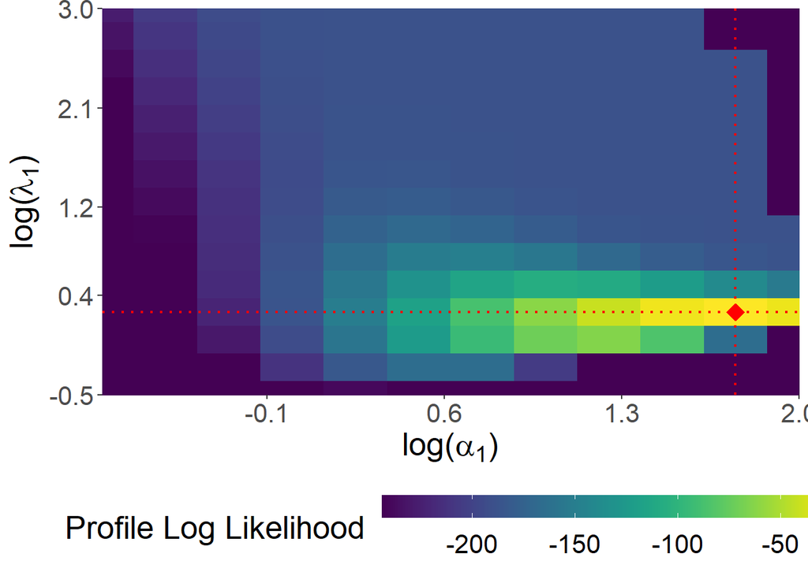

```r
plot_LL(GPROF = opt_out$GPROF,GOPT = opt_out$GOPT)
```

## 2.2 Full simulation, multiple replicates

The code below performs a full simulation across multiple replicates.

```r
RR = 1e2 # number of replicates

sim_out = full_sim(copula = copula,
  dist1 = dist1,NN = NN,theta = theta,
  alpha1 = alpha1,lambda1 = lambda1,
  kappa1 = kappa1,alpha2 = alpha2,
  lambda2 = lambda2,propC = propC,RR = RR,
  param_grid = seq(-1,3,0.5),
  upKAPPA = 1,show = TRUE)
```

```
....................100 out of 100
```

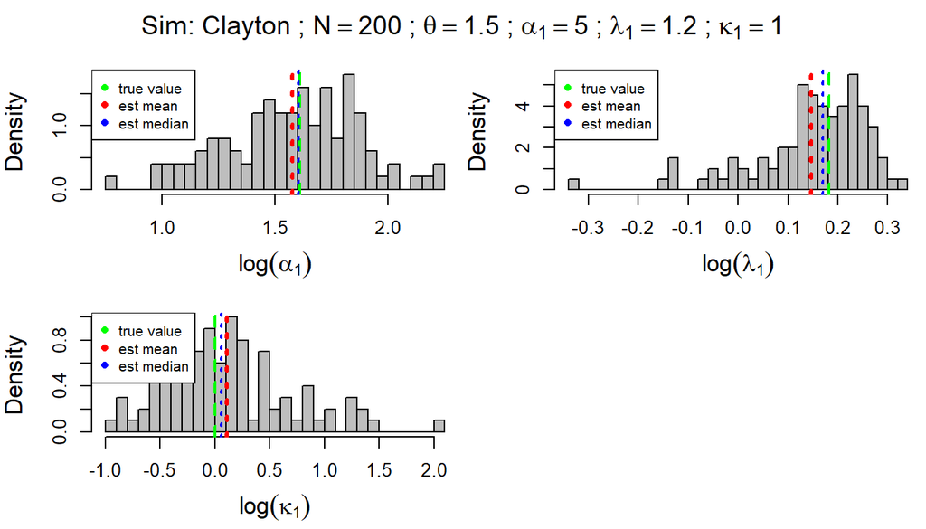

```r
sim_out
```

```
   copula        PARS  NN     TRUTH       EST        BIAS        SE       SEE
1 Clayton  log_alpha1 200 1.6094379 1.5755380 -0.03389993 0.2939006 0.2863270
2 Clayton log_lambda1 200 0.1823216 0.1465907 -0.03573082 0.1152794 0.1091123
3 Clayton  log_kappa1 200 0.0000000 0.1103650  0.11036504 0.5775604 0.5764676
4 Clayton   log_theta 200 0.4054651 0.4054651  0.00000000 0.0000000 0.0000000
    CP
1 0.93
2 0.96
3 0.97
4 1.00
```

# 3 Applying dMrs

Equivalently, we can run a formal analysis for various thetas, again with the simulated dataset.

```r
ana_out = run_analyses(DATA = one_rep$DATA,
    THETAs = c(0,one_rep$PARAMS$theta,2,5),copula = copula,
    param_grid = seq(-1,3,0.1),
    vec_time = seq(0,2 * max(one_rep$DATA$time),length.out = 50),
  upKAPPA = 0,show = TRUE)
```

```
Fri Nov 05 15:44:25 2021: theta = 0 ...
Fri Nov 05 15:44:25 2021: Grid search for initial parameters ...
Num grid points = 1681
...1681 out of 1681 done
Fri Nov 05 15:44:26 2021: Find all local optimums
..................................................500 out of 1681
..................................................1000 out of 1681
..................................................1500 out of 1681
..................1681 out of 1681
Fri Nov 05 15:44:36 2021: Two-dimensional plot of the log likelihood ...
```

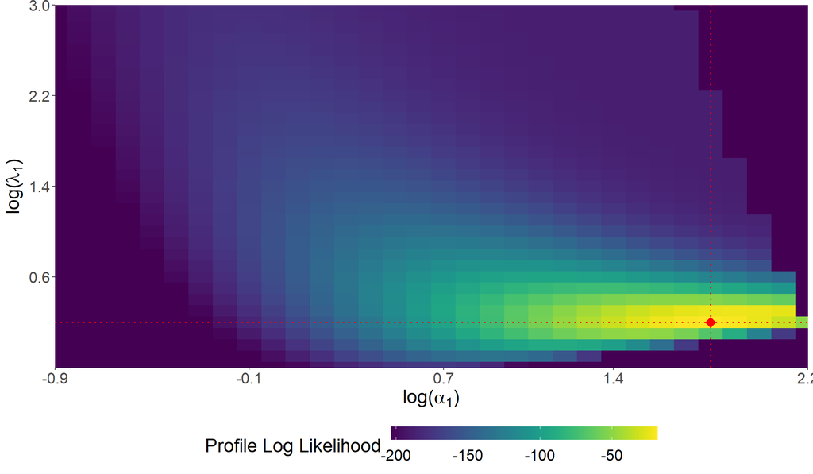

```
Fri Nov 05 15:44:36 2021: BFGS optimization ...
.
Fri Nov 05 15:44:36 2021: Get covariance ...
Fri Nov 05 15:44:36 2021: theta = 1.5 ...
Fri Nov 05 15:44:36 2021: Grid search for initial parameters ...
Num grid points = 1681
...1681 out of 1681 done
Fri Nov 05 15:44:37 2021: Find all local optimums
..................................................500 out of 1681
..................................................1000 out of 1681
..................................................1500 out of 1681
..................1681 out of 1681
Fri Nov 05 15:44:47 2021: Two-dimensional plot of the log likelihood ...
```

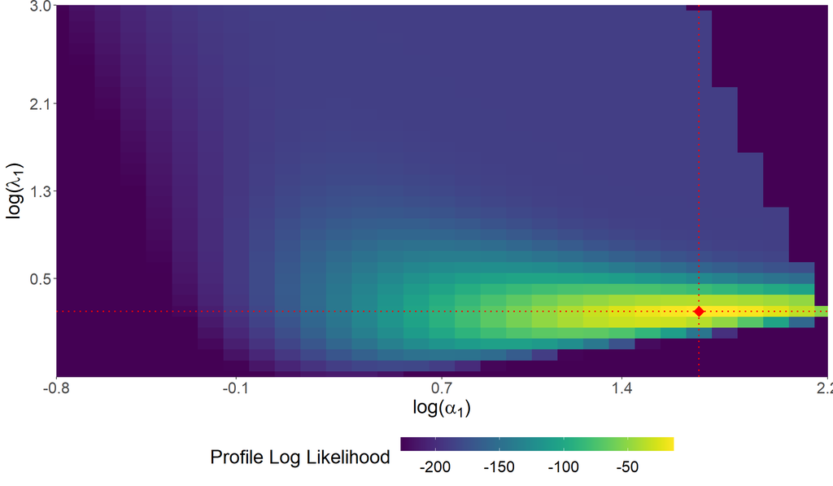

```
Fri Nov 05 15:44:48 2021: BFGS optimization ...
.
Fri Nov 05 15:44:48 2021: Get covariance ...
Fri Nov 05 15:44:48 2021: theta = 2 ...
Fri Nov 05 15:44:48 2021: Grid search for initial parameters ...
Num grid points = 1681
...1681 out of 1681 done
Fri Nov 05 15:44:49 2021: Find all local optimums
..................................................500 out of 1681
..................................................1000 out of 1681
..................................................1500 out of 1681
..................1681 out of 1681
Fri Nov 05 15:44:59 2021: Two-dimensional plot of the log likelihood ...
```

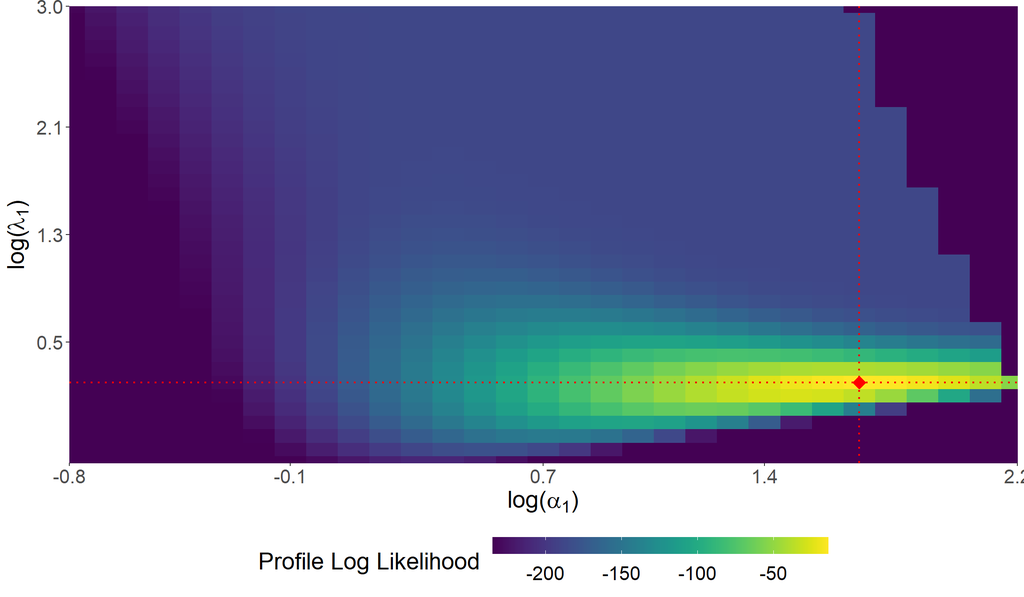

```
Fri Nov 05 15:44:59 2021: BFGS optimization ...
.
Fri Nov 05 15:44:59 2021: Get covariance ...
Fri Nov 05 15:44:59 2021: theta = 5 ...
Fri Nov 05 15:44:59 2021: Grid search for initial parameters ...
Num grid points = 1681
...1681 out of 1681 done
Fri Nov 05 15:45:00 2021: Find all local optimums
..................................................500 out of 1681
..................................................1000 out of 1681
..................................................1500 out of 1681
..................1681 out of 1681
Fri Nov 05 15:45:11 2021: Two-dimensional plot of the log likelihood ...
```

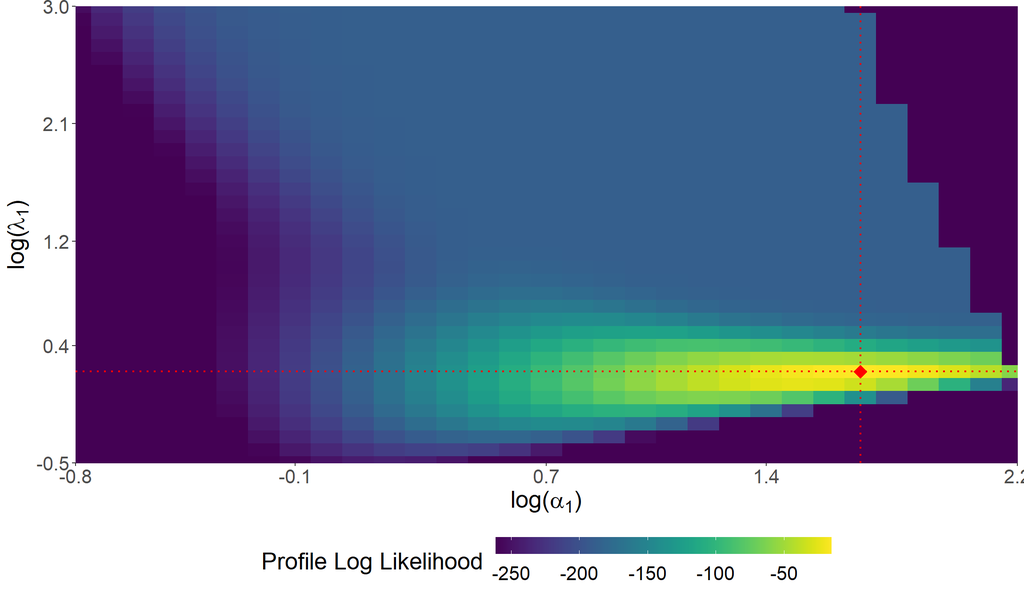

```
Fri Nov 05 15:45:11 2021: BFGS optimization ...
.
Fri Nov 05 15:45:11 2021: Get covariance ...
```

```r
names(ana_out)
```

```
[1] "theta = 0"   "theta = 1.5" "theta = 2"   "theta = 5"
```

```r
# Estimates per theta
bb = sapply(names(ana_out),function(xx){
    # xx = names(run_ana)[1]; xx
    cat("\n#######\n")
    print(xx)
    print(ana_out[[xx]]$RES$cout[,c("PARS","EST","lowCI_2","highCI_2")])
    print(sprintf("LL = %s",round(ana_out[[xx]]$RES$LL,3)))
    print(round(ana_out[[xx]]$PRED[1:5,c("time","surv",
        "low_surv2","high_surv2")],3))
})
```

```
#######
[1] "theta = 0"
     PARS      EST  lowCI_2 highCI_2
1  alpha1 6.569228 5.682733 7.594015
2 lambda1 1.269301 1.231407 1.308361
3  kappa1 1.000000 1.000000 1.000000
4   theta 0.000000 0.000000 0.000000
[1] "LL = -15.823"
   time surv low_surv2 high_surv2
1 0.000    1         1          1
2 0.067    1         1          1
3 0.135    1         1          1
4 0.202    1         1          1
5 0.269    1         1          1

```

[output cut: 44 more lines]

Below we plot the corresponding predicted survival with 95% confidence bands. In the latter figure, we can see the corresponding maximum log likelihood estimates per theta.

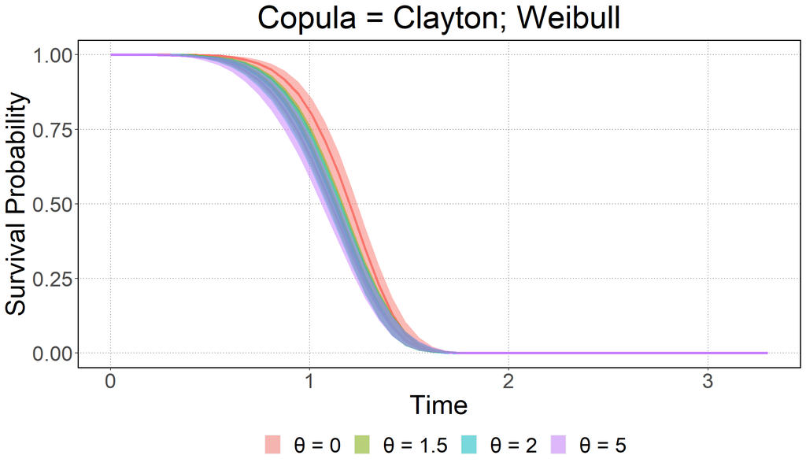

```r
plot_SURVs(run_ANA = ana_out,MULTIPLE = FALSE,ALPHA = 0.5)
```

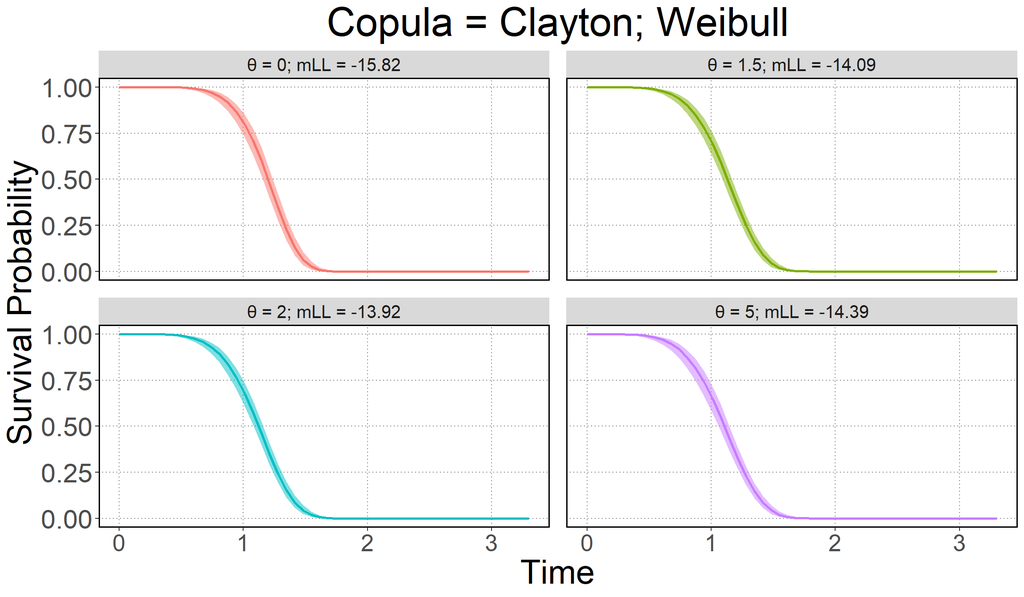

```r
plot_SURVs(run_ANA = ana_out,MULTIPLE = TRUE,ALPHA = 0.5)
```

# 5 References